# Support Vector Machines(SVMs) Tutorial

```r
svm.linear_test = predict(svm.linear, newdata = carseats[-train,])
confusionMatrix(svm.linear_test, reference = carseats[-train,]$High)
```

```
## Confusion Matrix and Statistics
##
##           Reference
## Prediction No Yes
##        No  76  19
##        Yes 12  43
##
##                Accuracy : 0.7933
##                  95% CI : (0.7197, 0.8551)
##     No Information Rate : 0.5867
##     P-Value [Acc > NIR] : 6.8e-08
##
##                   Kappa : 0.5666
##
##  Mcnemar's Test P-Value : 0.2812
##
##             Sensitivity : 0.8636
##             Specificity : 0.6935
##          Pos Pred Value : 0.8000
##          Neg Pred Value : 0.7818
##              Prevalence : 0.5867
##          Detection Rate : 0.5067
##    Detection Prevalence : 0.6333
##       Balanced Accuracy : 0.7786
##
##        'Positive' Class : No
##
```

```r
# IN RESPECT OF THE REVISED SVM MODEL WITH A LINEAR KERNEL, ITS TEST ACCURACY SCORE OF 0.7933 IS LESS THAN THE ORIGINAL RESPECTIVE MODEL'S TEST ACCURACY SCORE OF 0.8733. IN THIS CASE, FEATURE SELECTION HAS NOT IMPROVED THE MODEL.
```

2. RADIAL

```r
set.seed(1112)
control = trainControl(method = "repeatedcv", repeats = 5, classProbs = T, savePredictions = T)

svm.radial = train(High ~ CompPrice + Income + Advertising + Population + ShelveLoc + Age + Education + US, carseats, subset=train, method = "svmRadial", tuneLength = 10, trControl = control)

svm.radial
```

```
## Support Vector Machines with Radial Basis Function Kernel
##
## 400 samples
##   8 predictor
##   2 classes: 'No', 'Yes'
##
## No pre-processing
## Resampling: Cross-Validated (10 fold, repeated 5 times)
## Summary of sample sizes: 226, 225, 224, 225, 225, 225, ...
## Resampling results across tuning parameters:
##
##   C       Accuracy   Kappa
##     0.25  0.7016462  0.3533232
##     0.50  0.6984385  0.3494338
##     1.00  0.7001692  0.3590143
##     2.00  0.7098974  0.3812020
##     4.00  0.7026590  0.3632476
##     8.00  0.7017590  0.3614201
##    16.00  0.6946282  0.3457806
##    32.00  0.6676744  0.2762150
##    64.00  0.6564590  0.2505188
##   128.00  0.6583205  0.2620817
##
## Tuning parameter 'sigma' was held constant at a value of 0.06958086
## Accuracy was used to select the optimal model using the largest value.
## The final values used for the model were sigma = 0.06958086 and C = 2.
```

```r
roc(predictor = svm.radial$pred$Yes, response = svm.radial$pred$obs)$auc
```

```
## Area under the curve: 0.7554
```

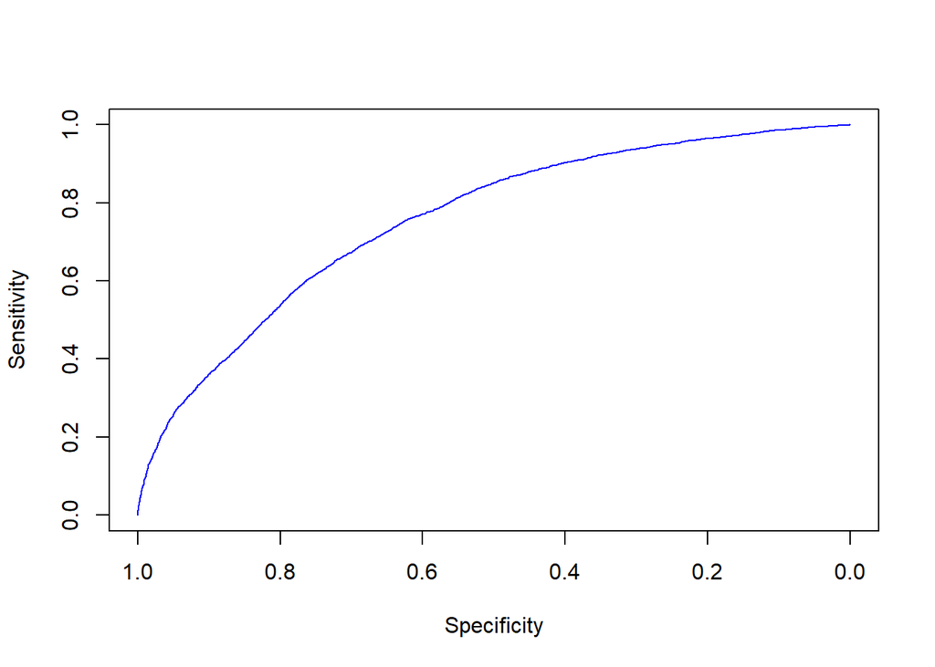

```r
plot(x = roc(predictor = svm.radial$pred$Yes, response = svm.radial$pred$obs)$specificities, y = roc(svm.radial$pred$Yes, response = svm.radial$pred$obs)$sensitivities, col= "blue", xlim = c(1, 0), type ="l", ylab = "Sensitivity", xlab = "Specificity")
```

```r
svm.radial_test = predict(svm.radial, newdata = carseats[-train,])
confusionMatrix(svm.radial_test, reference = carseats[-train,]$High)
```

```
## Confusion Matrix and Statistics
##
##           Reference
## Prediction No Yes
##        No  75  21
##        Yes 13  41
##
##                Accuracy : 0.7733
##                  95% CI : (0.6979, 0.8376)
##     No Information Rate : 0.5867
##     P-Value [Acc > NIR] : 1.168e-06
##
##                   Kappa : 0.5235
##
##  Mcnemar's Test P-Value : 0.2299
##
##             Sensitivity : 0.8523
##             Specificity : 0.6613
##          Pos Pred Value : 0.7812
##          Neg Pred Value : 0.7593
##              Prevalence : 0.5867
##          Detection Rate : 0.5000
##    Detection Prevalence : 0.6400
##       Balanced Accuracy : 0.7568
##
##        'Positive' Class : No
##
```

```r
# IN RESPECT OF THE REVISED SVM MODEL WITH A RADIAL KERNEL, ITS TEST ACCURACY SCORE OF 0.7733 IS LESS THAN THE ORIGINAL RESPECTIVE MODEL'S TEST ACCURACY SCORE OF 0.8733. FURTHERMORE, IT'S SCORE IS WORSE THAN THE REVISED LINEAR MODEL'S SCORE OF 0.7933 - ORIGINALLY, THE LINEAR AND RADIAL TEST ACCURACY SCORES WERE EQUAL. IN THIS CASE, FEATURE SELECTION HAS NOT IMPROVED THE MODEL.
```

CONCLUSION

Feature selection is not necessary for the SVM algorithm. It is because SVM already embeds a feature selection with the regularization term controlled by the C parameter. The C parameter can indeed be seen as a parameter controlling the number of features to select by the SVM for classification, and the kernel function is there to build an appropriate feature space.

What is however important is to optimize the C parameter, and eventually the kernel function. If such optimisation is undertaken, most of the feature selection methods should decrease SVM classification performance because they are not aware of the classification algorithm - and then there is a risk of eliminating pertinent features.